# a3_task4_mikel_irigoyen.Rmd

Mikel irigoyen

11/1/2020

## In this section wecompare the mean size of purple urchins in CONTROL (no giant kelp removal) or ANNUAL (annual kelp removal) sections of Naples Reef in January 2010.

- here i read in the data and clean_names

```r
urchins <- read_csv(here("data", "urchins.csv")) %>%
  clean_names()
```

###Wrangling data to only include Naples Reef observations for purple urchins observed in January 2010

- Included some previously used code from task 3
- Began by using lubridate to format dates
- Then used case_when() to refer to NAPL by its full name in new column
- After that used case_when() to create annual and control in its own column
- Then used filter() to only see Naples observations for the month/year that we are looking for.

```r
naples_obs <- urchins %>%

 mutate(date = mdy(date),
        month = month(date),
        year = year(date),
        site_full = case_when(site == "NAPL" ~ "Naples Reef")) %>%
  mutate(treatment = case_when(treatment == "ANNUAL" ~ "annual", treatment == "CONTROL" ~ "control")) %>%
  filter(common_name == "Purple Urchin", site == "NAPL",
         month == 1, year == 2010)
```

## Histograms and QQ-plots

- Using these to look at the size distribution for each of the treatments (Control and Annual) in order to assess normality
- First up is the histogram, used facet_wrap() to get separate plots for both treatment types

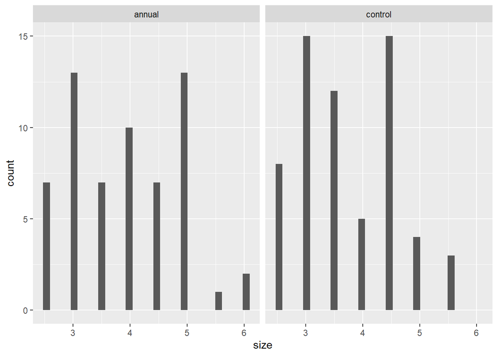

```r
ggplot(naples_obs, aes(size)) +
  geom_histogram()+
  facet_wrap(~treatment)
```

- Next we do the qq-plot

- Same procedure that was used on the histogram to get results
- One difference being, qq-plots require knowing a sample, so must include “sample = size”

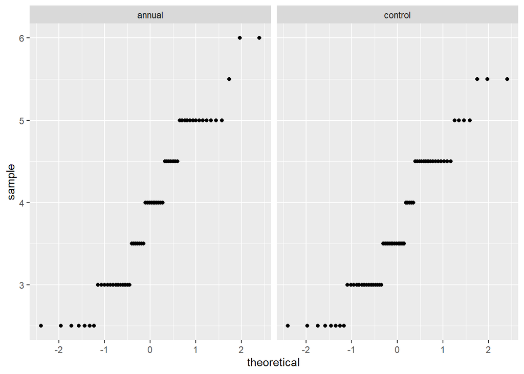

```r
ggplot(naples_obs, aes(sample = size))+
  geom_qq()+
  facet_wrap(~treatment)
```

- The histograms show a relatively normal distribution and the linear trend in the qq-plots do as well. This shows normality between the two types of urchins.

## Summary Statistics Time!!!

- Here we create a basic table of descriptive statistics for both groups that will include the mean, standard deviation, and sample size

```r
purp_urch_stats <- naples_obs %>%
  group_by(treatment) %>%
  summarize(naples_mean = mean(size),
            naples_sd = sd(size),
            count = n())
print(purp_urch_stats)
```

```
## # A tibble: 2 x 4
##   treatment naples_mean naples_sd count
##   <chr>           <dbl>     <dbl> <int>
## 1 annual           3.92     0.966    60
## 2 control          3.73     0.867    62
```

## T-test time

- Here we perform a two-sample t-test to compare means between the two groups
- Created separate vectors differentiated by “treatment”
- Pull by “size”
- Then do a t-test with annual vs. control

```r
ann_urchins <- naples_obs %>%
  filter(treatment == "annual") %>%
  pull(size)
```

```r
con_urchins <- naples_obs %>%
  filter(treatment == "control") %>%
  pull(size)
```

```r
t.test(x = ann_urchins, y = con_urchins)
```

```
##
##  Welch Two Sample t-test
##
## data:  ann_urchins and con_urchins
## t = 1.1472, df = 117.66, p-value = 0.2536
## alternative hypothesis: true difference in means is not equal to 0
## 95 percent confidence interval:
##  -0.1386165  0.5203369
## sample estimates:
## mean of x mean of y
##  3.916667  3.725806
```